# Forecasting with Boosted Decision Trees and Threshold Autoregressive Models

I-Lun, Tu

# 1. Boosted Decision Trees with LightGBM

## (1) Introduction

We framed the problem of deciding whether or not to buy certain ETFs before the market closed as classification problems in the statistical learning/ machine learning context. That is, if the following day’s opening price was higher than today’s close price (positive return), our model should provide us with a signal. On the other hand, for a negative return, our model should indicate a sell signal. We modeled each of the 6 ETFs separately. However, we used the same statistical learning framework but with different parameters to optimize the results.

## (2) Methodology

### a. Statistical Learning Models

The Boosted decision tree with LightGBM framework was utilized for handling the classification tasks. LightGBM was known for its accuracy in prediction and efficiency in execution. LightGBM was on par, if not slightly better, than the XGBoost framework, with which many teams won the Kaggle data competitions several years ago. Also, in the current literature on short-term stock movement prediction, boosted decision tree was consistently one of the top-performing models.

## (3) Backtesting Frameworks

### a. Backtesting Frameworks

The data started from 2018-01-01 to 2022-05-31. The idea was that we should not use data too long ago, or we would risk making obsolete models. Also, due to the time-series nature of the data, we trained, validated, and tested models using the below three different frameworks. The first one was the most straightforward testing framework. The second one intended to keep the models as up-to-date as possible. The third one was designed to make the models use as much information as possible.

### e. Model Testing Results

- **Positive Percentage:** among all the days in the testing data, what proportion of days came with a positive return.
- **Validation Accuracy:** the highest accuracy achieved when adjusting/ tuning the models using validation data.
- **Testing Accuracy:** the accuracy when the models were tested on the never-before-seen data. The larger the discrepancy between testing accuracy and validation accuracy, the stronger the indication that the underlying market was harder to predict for this model.
- **True Positive:** among those days with positive returns, what proportion was correctly identified by the model.
- **True Negative:** among those days with negative returns, what proportion was correctly identified by the model. (Low True Negative suggested a higher rate of false-positive)
- **Long Signal:** the number of times the models predicted that we should buy.
- **Long:** the resulting profit if we only placed long position entirely according to the models.
- **Short Signal:** the number of times the models predicted that we should sell/ not buy.
- **Short:** the resulting profit if we only placed short position entirely according to the models.
- **Long Short:** the resulting profit if we place both long and short positions entirely according to the models.

## (4) Model Testing Results

### a. Simple Training-Validation-Testing Splits

Classification Accuracy

|  | Posive.Percentage | Validation.Accuracy | Testing.Accuracy | True.Positive | True.Negative |
| --- | --- | --- | --- | --- | --- |
| EEMA | 43.22% | 52.32% | 49.15% | 70.59% | 32.84% |
| SCJ | 50.00% | 52.32% | 48.31% | 72.88% | 23.73% |
| EWJ | 48.31% | 54.30% | 48.31% | 75.44% | 22.95% |
| AAXJ | 46.61% | 54.30% | 59.32% | 56.36% | 61.90% |
| IEFA | 44.07% | 62.25% | 57.63% | 80.77% | 39.39% |
| IEMG | 47.46% | 61.59% | 54.24% | 39.29% | 67.74% |

Trading Results

|  | Long.Signal | Long | Short.Signal | Short | Long.Short |
| --- | --- | --- | --- | --- | --- |
| EEMA | 81 | -12.19% | 37 | 3.76% | -8.89% |
| SCJ | 88 | -5.51% | 30 | 3.02% | -2.66% |
| EWJ | 90 | -11.30% | 28 | 2.85% | -8.78% |
| AAXJ | 55 | 0.10% | 63 | 10.78% | 10.89% |
| IEFA | 82 | -2.24% | 36 | 11.13% | 8.65% |
| IEMG | 42 | -4.11% | 76 | 11.82% | 7.23% |

### b. Rolling-based Training-Validation-Testing Splits with fixed window

Classification Accuracy

|  | Posive.Percentage | Validation.Accuracy | Testing.Accuracy | True.Positive | True.Negative |
| --- | --- | --- | --- | --- | --- |
| EEMA | 43.22% | 50.99% | 46.61% | 15.69% | 70.15% |
| SCJ | 50.00% | 53.64% | 50.85% | 38.98% | 62.71% |
| EWJ | 48.31% | 56.95% | 48.31% | 33.33% | 62.30% |
| AAXJ | 46.61% | 52.98% | 54.24% | 32.73% | 73.02% |
| IEFA | 44.07% | 54.30% | 48.31% | 36.54% | 57.58% |
| IEMG | 47.46% | 58.94% | 56.78% | 46.43% | 66.13% |

Trading Results

|  | Long.Signal | Long | Short.Signal | Short | Long.Short |
| --- | --- | --- | --- | --- | --- |
| EEMA | 28 | -11.48% | 90 | 3.42% | -8.45% |
| SCJ | 45 | -4.42% | 73 | 3.83% | -0.76% |
| EWJ | 42 | -9.55% | 76 | 4.42% | -5.55% |
| AAXJ | 35 | 0.85% | 83 | 10.93% | 11.87% |
| IEFA | 47 | -3.05% | 71 | 9.72% | 6.37% |
| IEMG | 47 | -4.59% | 71 | 11.06% | 5.96% |

### c. Rolling-based Training-Validation-Testing Splits with enlarging window

Classification Accuracy

|  | Posive.Percentage | Validation.Accuracy | Testing.Accuracy | True.Positive | True.Negative |
| --- | --- | --- | --- | --- | --- |
| EEMA | 43.22% | 50.99% | 53.39% | 49.02% | 56.72% |
| SCJ | 50.00% | 53.64% | 48.31% | 55.93% | 40.68% |
| EWJ | 48.31% | 56.95% | 47.46% | 56.14% | 39.34% |
| AAXJ | 46.61% | 52.98% | 52.54% | 34.55% | 68.25% |
| IEFA | 44.07% | 54.30% | 47.46% | 57.69% | 39.39% |
| IEMG | 47.46% | 58.94% | 46.61% | 48.21% | 45.16% |

Trading Results

|  | Long.Signal | Long | Short.Signal | Short | Long.Short |
| --- | --- | --- | --- | --- | --- |
| EEMA | 54 | -2.59% | 64 | 14.53% | 11.56% |
| SCJ | 68 | -6.96% | 50 | 1.26% | -5.79% |
| EWJ | 69 | -11.14% | 49 | 2.84% | -8.61% |
| AAXJ | 39 | -2.74% | 79 | 7.13% | 4.20% |
| IEFA | 70 | -9.25% | 48 | 2.97% | -6.56% |
| IEMG | 61 | -13.30% | 57 | 1.41% | -12.08% |

## (6) Possible Improvement & Further Research Direction

The set of technical indicators utilized in this study was suggested by previous researches and were composed of many commonly used indicators. With some experimentations, we discovered that this set indeed help the model achieve higher accuracy. However, as we understood there were many more potentially useful indicators, and more importantly, there were exponentially more combinations of these indicators.

Moving forward, we would like to use genetic algorithm to systemically explore the vast number of possible combinations. Also, to make more use of the time-series structure of the data, we would also like to experiment with the SPADE algorithm to extract other possible trading signals. Our goal was to uniformly increase the overall accuracy in the previously mentioned metrics to around 55%.

# 2. Dynamic Time Series Models - Threshold AutoRegressive Models

## (1) Introduction

The primary reasons behind the under-performing boosted decision tree models might be that they were not “dynamic” enough in the sense that they had to balance many data points in the past. Often, short-term movements were more heavily influenced by certain recent factors, and even with similar information from our selected covariates, we would not have a better chance of predicting the correct movements, if the underlying market conditions were different.

Therefore, we turned to use the more straightforward and more compatible time series models. We selected the Threshold AutoRegressive models. The idea was that we not only wanted to model the price movement from fewer past instances, but more importantly, we intended to capture how the market would react or how the market conditions would change when the price reached certain levels/ thresholds. We experimented with different thresholds and discovered the quality of predictions was reasonably well (around 62% directional accuracy for some of our targets).

## (2) Training and Validation Process

For time series models, a more traditional AIC/ BIC criterion selection methods were used. That is, the data set was splited between training and testing. After training on the training data set, the selected time series model was used to predict out-of-sample testing data set to calculate the directional accuracy and the resulting profit.

## (3) Profit Calculation

Based on the below testings starting from 2022-01-01, we could see that there seemed to be some earning potential for EEMA and AAXJ for both the long and short positions. Hence, we suggested focusing more on these ETFs. Overall speaking, assuming short positions tended to generate more profits compared with assuming long positions, although, of course, it was more risky and costly to assume the short position. (Notice there were cut-off value set at the medium of the negative prediction to safeguard against short selling)

### a. Long Position

- Market Long: the highest possible return for next-day trade from going long
- Model Long: the return from going long according to the model
- Everyday Long: the return from going long everyday

#### EEMA

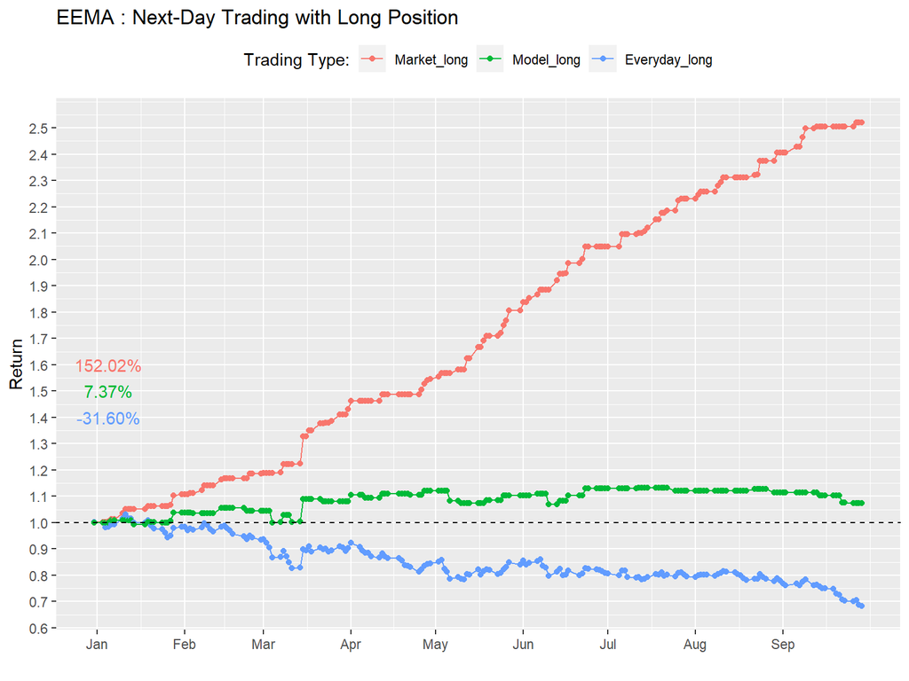

| Date | Buy | Invested Return | Actual Return | Daily Trade Return | Total Cumulative Return |
| --- | --- | --- | --- | --- | --- |
| 12/31/21 |  | 0.0000% | 0.1827% | 0 | 0 |
| 01/03/22 |  | 0.0000% | -0.2315% | 0 | 0 |
| 01/04/22 |  | 0.0000% | -1.7719% | 0 | 0 |
| 01/05/22 |  | 0.0000% | 0.2727% | 0 | 0 |
| 01/06/22 | * | 0.8997% | 0.8997% | 899,745 | 899,745 |
| 01/07/22 |  | 0.0000% | 0.0736% | 0 | 899,745 |
| 01/10/22 |  | 0.0000% | 2.1590% | 0 | 899,745 |
| 01/11/22 |  | 0.0000% | 1.5715% | 0 | 899,745 |
| 01/12/22 |  | 0.0000% | -1.5115% | 0 | 899,745 |
| 01/13/22 |  | 0.0000% | 0.0000% | 0 | 899,745 |

[output cut: 178 more lines]

#### SCJ

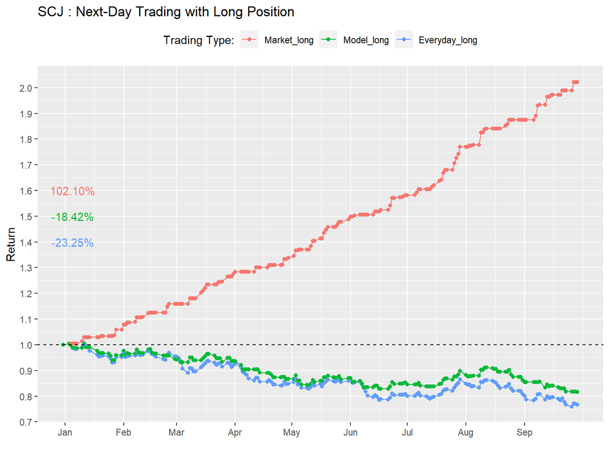

| Date | Buy | Invested Return | Actual Return | Daily Trade Return | Total Cumulative Return |
| --- | --- | --- | --- | --- | --- |
| 12/31/21 |  | 0.0000% | -0.0133% | 0 | 0 |
| 01/03/22 | * | 0.4901% | 0.4901% | 490,102 | 490,102 |
| 01/04/22 | * | -0.7028% | -0.7028% | -702,778 | -216,120 |
| 01/05/22 | * | -1.0030% | -1.0030% | -1,003,017 | -1,216,970 |
| 01/06/22 |  | 0.0000% | -0.3501% | 0 | -1,216,970 |
| 01/07/22 |  | 0.0000% | -0.1890% | 0 | -1,216,970 |
| 01/10/22 |  | 0.0000% | 0.8879% | 0 | -1,216,970 |
| 01/11/22 | * | 1.5022% | 1.5022% | 1,502,184 | 266,933 |
| 01/12/22 | * | -1.1279% | -1.1279% | -1,127,855 | -863,932 |
| 01/13/22 | * | -0.0133% | -0.0133% | -13,348 | -877,165 |

[output cut: 178 more lines]

#### EWJ

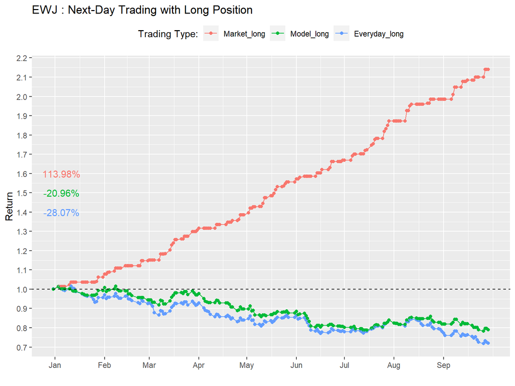

| Date | Buy | Invested Return | Actual Return | Daily Trade Return | Total Cumulative Return |
| --- | --- | --- | --- | --- | --- |
| 12/31/21 |  | 0.0000% | 0.1045% | 0 | 0 |
| 01/03/22 | * | 1.3043% | 1.3043% | 1,304,309 | 1,304,309 |
| 01/04/22 | * | -0.4575% | -0.4575% | -457,540 | 840,801 |
| 01/05/22 | * | -0.7424% | -0.7424% | -742,394 | 92,165 |
| 01/06/22 |  | 0.0000% | -0.6429% | 0 | 92,165 |
| 01/07/22 |  | 0.0000% | -0.2403% | 0 | 92,165 |
| 01/10/22 |  | 0.0000% | 0.7788% | 0 | 92,165 |
| 01/11/22 |  | 0.0000% | 1.4220% | 0 | 92,165 |
| 01/12/22 | * | -1.0052% | -1.0052% | -1,005,182 | -913,944 |
| 01/13/22 | * | -0.1189% | -0.1189% | -118,916 | -1,031,773 |

[output cut: 178 more lines]

#### AAXJ

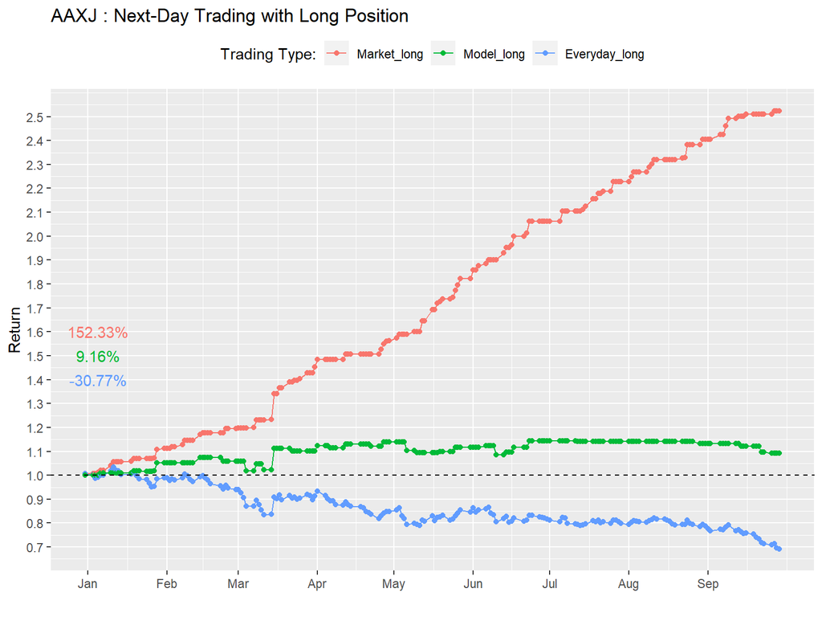

| Date | Buy | Invested Return | Actual Return | Daily Trade Return | Total Cumulative Return |
| --- | --- | --- | --- | --- | --- |
| 12/31/21 |  | 0.0000% | 0.7109% | 0 | 0 |
| 01/03/22 |  | 0.0000% | -0.4091% | 0 | 0 |
| 01/04/22 |  | 0.0000% | -1.6776% | 0 | 0 |
| 01/05/22 |  | 0.0000% | 0.4770% | 0 | 0 |
| 01/06/22 | * | 0.9351% | 0.9351% | 935,102 | 935,102 |
| 01/07/22 |  | 0.0000% | -0.0605% | 0 | 935,102 |
| 01/10/22 |  | 0.0000% | 1.9760% | 0 | 935,102 |
| 01/11/22 |  | 0.0000% | 1.4948% | 0 | 935,102 |
| 01/12/22 |  | 0.0000% | -1.3170% | 0 | 935,102 |
| 01/13/22 |  | 0.0000% | -0.1421% | 0 | 935,102 |

[output cut: 178 more lines]

#### IEFA

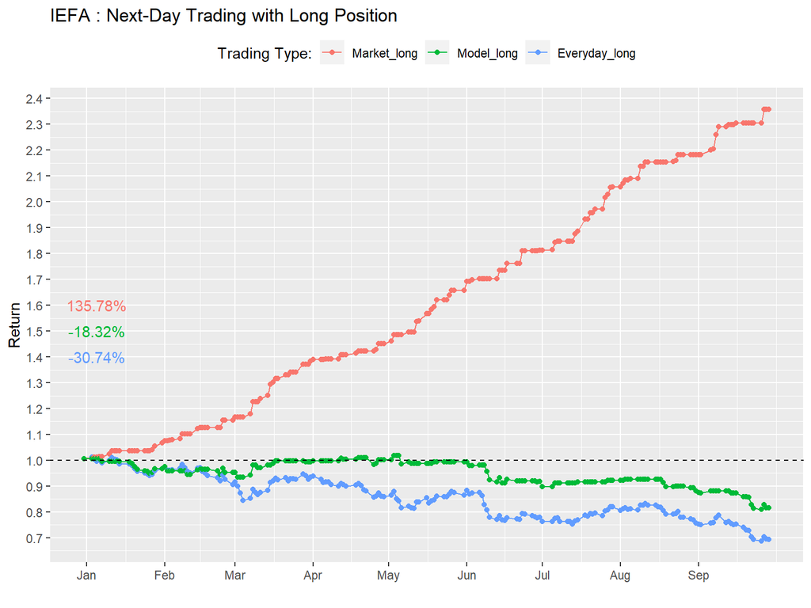

| Date | Buy | Invested Return | Actual Return | Daily Trade Return | Total Cumulative Return |
| --- | --- | --- | --- | --- | --- |
| 12/31/21 | * | 0.5611% | 0.5611% | 561,122 | 561,122 |
| 01/03/22 |  | 0.0000% | 0.5580% | 0 | 561,122 |
| 01/04/22 |  | 0.0000% | -0.8114% | 0 | 561,122 |
| 01/05/22 |  | 0.0000% | -0.6432% | 0 | 561,122 |
| 01/06/22 |  | 0.0000% | 0.2953% | 0 | 561,122 |
| 01/07/22 | * | -1.0239% | -1.0239% | -1,023,858 | -468,481 |
| 01/10/22 |  | 0.0000% | 1.0909% | 0 | -468,481 |
| 01/11/22 |  | 0.0000% | 1.0658% | 0 | -468,481 |
| 01/12/22 |  | 0.0000% | -0.7716% | 0 | -468,481 |
| 01/13/22 |  | 0.0000% | -0.1203% | 0 | -468,481 |

[output cut: 178 more lines]

#### IEMG

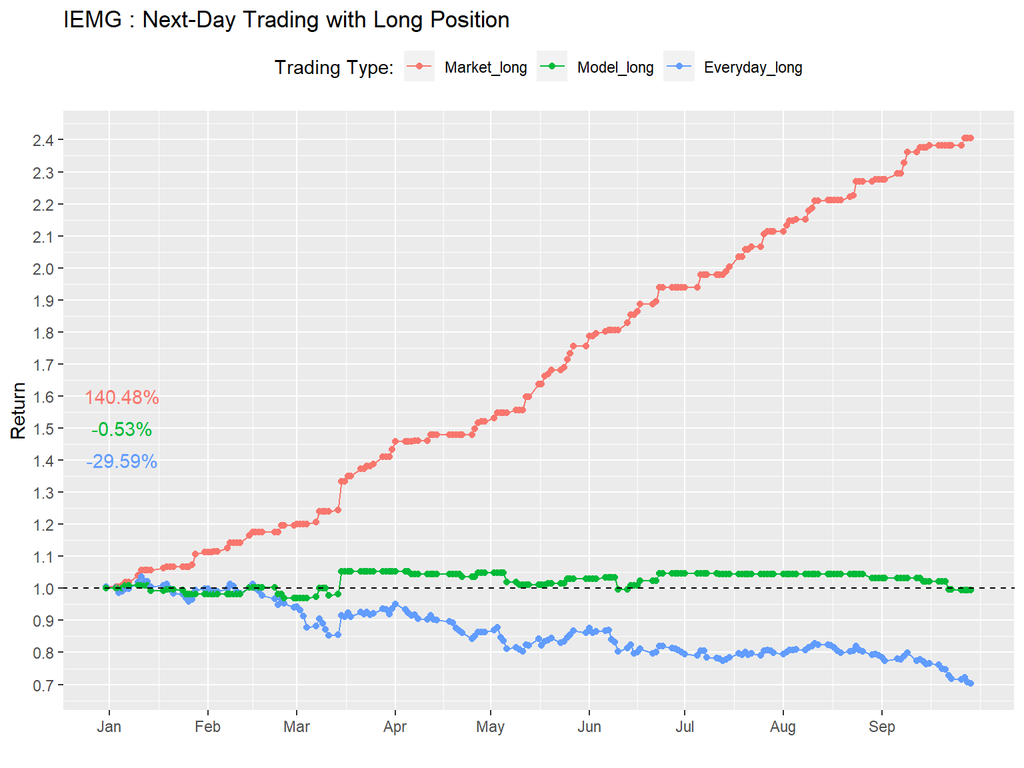

| Date | Buy | Invested Return | Actual Return | Daily Trade Return | Total Cumulative Return |
| --- | --- | --- | --- | --- | --- |
| 12/31/21 |  | 0.0000% | 0.5830% | 0 | 0 |
| 01/03/22 |  | 0.0000% | -0.3827% | 0 | 0 |
| 01/04/22 |  | 0.0000% | -1.5119% | 0 | 0 |
| 01/05/22 |  | 0.0000% | 0.3717% | 0 | 0 |
| 01/06/22 | * | 0.8898% | 0.8898% | 889,795 | 889,795 |
| 01/07/22 |  | 0.0000% | -0.0836% | 0 | 889,795 |
| 01/10/22 |  | 0.0000% | 2.1186% | 0 | 889,795 |
| 01/11/22 |  | 0.0000% | 1.6406% | 0 | 889,795 |
| 01/12/22 |  | 0.0000% | -1.4279% | 0 | 889,795 |
| 01/13/22 |  | 0.0000% | -0.0163% | 0 | 889,795 |

[output cut: 178 more lines]

### b. Short Position

- Market Short: the highest possible return for next-day trade from going short
- Model Short: the return from going short according to the model
- Everyday Short: the return from going short everyday

#### EEMA

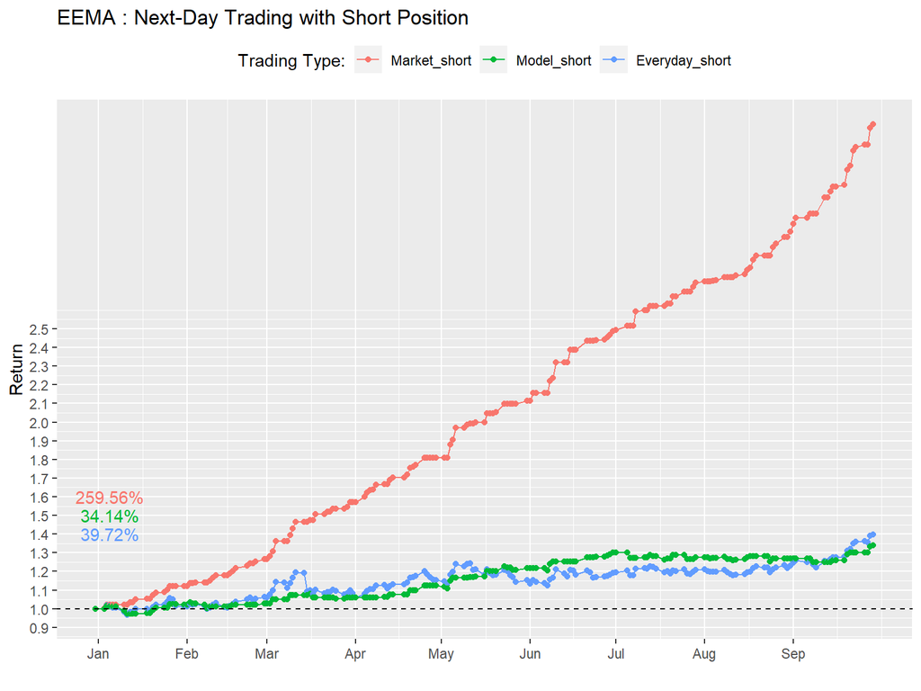

| Date | Sell | Invested Return | Actual Return | Daily Trade Return | Total Cumulative Return |
| --- | --- | --- | --- | --- | --- |
| 12/31/21 | * | -0.1827% | 0.1827% | -182,694 | -182,694 |
| 01/03/22 |  | 0.0000% | -0.2315% | 0 | -182,694 |
| 01/04/22 | * | 1.7719% | -1.7719% | 1,771,912 | 1,585,980 |
| 01/05/22 | * | -0.2727% | 0.2727% | -272,743 | 1,308,912 |
| 01/06/22 |  | 0.0000% | 0.8997% | 0 | 1,308,912 |
| 01/07/22 | * | -0.0736% | 0.0736% | -73,590 | 1,234,359 |
| 01/10/22 | * | -2.1590% | 2.1590% | -2,158,966 | -951,256 |
| 01/11/22 | * | -1.5715% | 1.5715% | -1,571,470 | -2,507,778 |
| 01/12/22 |  | 0.0000% | -1.5115% | 0 | -2,507,778 |
| 01/13/22 |  | 0.0000% | 0.0000% | 0 | -2,507,778 |

[output cut: 178 more lines]

#### SCJ

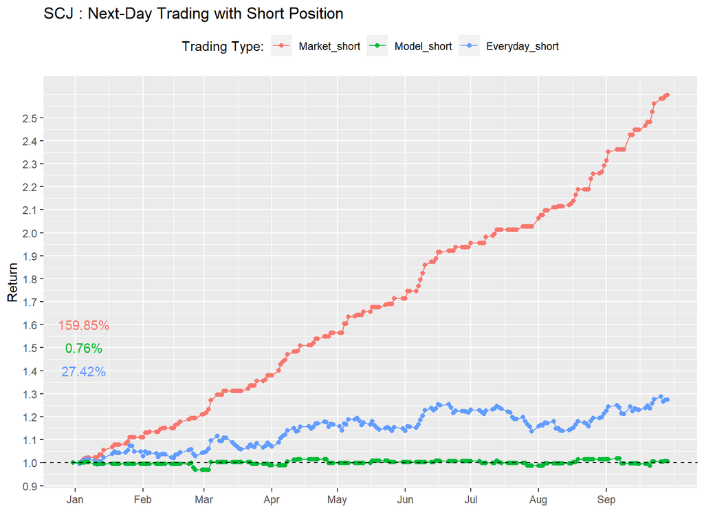

| Date | Sell | Invested Return | Actual Return | Daily Trade Return | Total Cumulative Return |
| --- | --- | --- | --- | --- | --- |
| 12/31/21 | * | 0.0133% | -0.0133% | 13,280 | 13,280 |
| 01/03/22 |  | 0.0000% | 0.4901% | 0 | 13,280 |
| 01/04/22 |  | 0.0000% | -0.7028% | 0 | 13,280 |
| 01/05/22 |  | 0.0000% | -1.0030% | 0 | 13,280 |
| 01/06/22 | * | 0.3501% | -0.3501% | 350,078 | 363,405 |
| 01/07/22 |  | 0.0000% | -0.1890% | 0 | 363,405 |
| 01/10/22 | * | -0.8879% | 0.8879% | -887,943 | -527,765 |
| 01/11/22 |  | 0.0000% | 1.5022% | 0 | -527,765 |
| 01/12/22 |  | 0.0000% | -1.1279% | 0 | -527,765 |
| 01/13/22 |  | 0.0000% | -0.0133% | 0 | -527,765 |

[output cut: 178 more lines]

#### EWJ

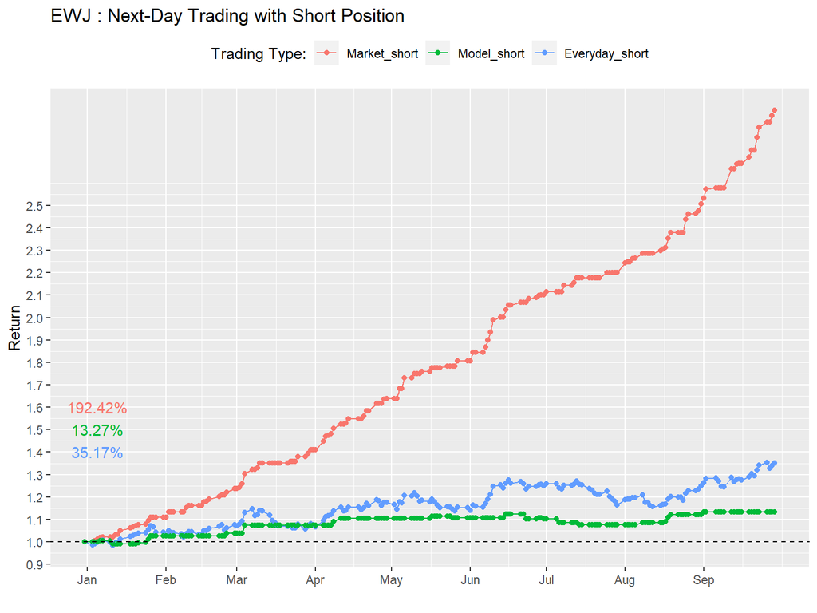

| Date | Sell | Invested Return | Actual Return | Daily Trade Return | Total Cumulative Return |
| --- | --- | --- | --- | --- | --- |
| 12/31/21 | * | -0.1045% | 0.1045% | -104,485 | -104,485 |
| 01/03/22 |  | 0.0000% | 1.3043% | 0 | -104,485 |
| 01/04/22 |  | 0.0000% | -0.4575% | 0 | -104,485 |
| 01/05/22 |  | 0.0000% | -0.7424% | 0 | -104,485 |
| 01/06/22 | * | 0.6429% | -0.6429% | 642,897 | 537,740 |
| 01/07/22 |  | 0.0000% | -0.2403% | 0 | 537,740 |
| 01/10/22 |  | 0.0000% | 0.7788% | 0 | 537,740 |
| 01/11/22 | * | -1.4220% | 1.4220% | -1,422,034 | -891,941 |
| 01/12/22 |  | 0.0000% | -1.0052% | 0 | -891,941 |
| 01/13/22 |  | 0.0000% | -0.1189% | 0 | -891,941 |

[output cut: 178 more lines]

#### AAXJ

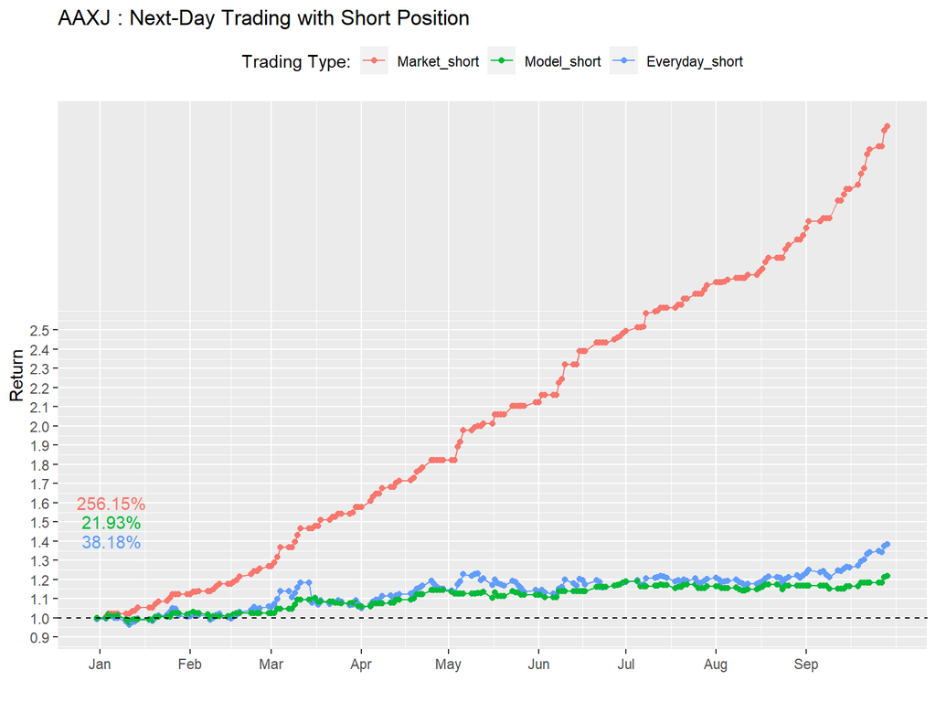

| Date | Sell | Invested Return | Actual Return | Daily Trade Return | Total Cumulative Return |
| --- | --- | --- | --- | --- | --- |
| 12/31/21 |  | 0.0000% | 0.7109% | 0 | 0 |
| 01/03/22 |  | 0.0000% | -0.4091% | 0 | 0 |
| 01/04/22 | * | 1.6776% | -1.6776% | 1,677,643 | 1,677,643 |
| 01/05/22 | * | -0.4770% | 0.4770% | -476,976 | 1,192,665 |
| 01/06/22 |  | 0.0000% | 0.9351% | 0 | 1,192,665 |
| 01/07/22 | * | 0.0605% | -0.0605% | 60,459 | 1,253,846 |
| 01/10/22 | * | -1.9760% | 1.9760% | -1,975,996 | -746,927 |
| 01/11/22 | * | -1.4948% | 1.4948% | -1,494,756 | -2,230,518 |
| 01/12/22 | * | 1.3170% | -1.3170% | 1,317,040 | -942,855 |
| 01/13/22 | * | 0.1421% | -0.1421% | 142,149 | -802,046 |

[output cut: 178 more lines]

#### IEFA

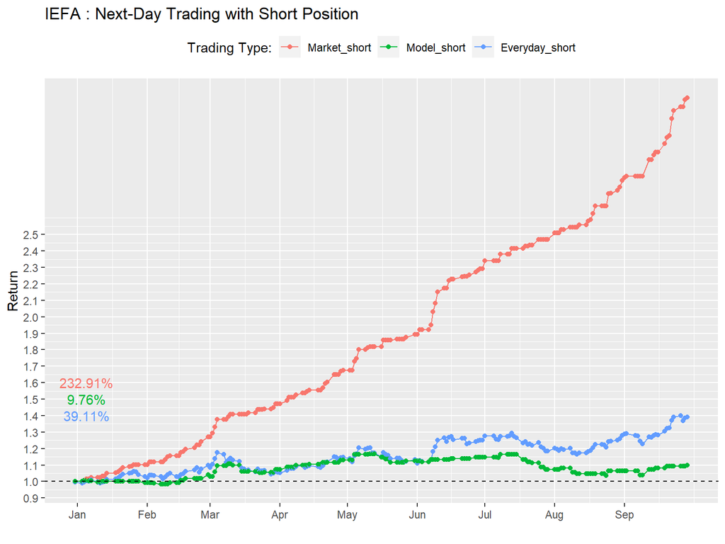

| Date | Sell | Invested Return | Actual Return | Daily Trade Return | Total Cumulative Return |
| --- | --- | --- | --- | --- | --- |
| 12/31/21 |  | 0.0000% | 0.5611% | 0 | 0 |
| 01/03/22 |  | 0.0000% | 0.5580% | 0 | 0 |
| 01/04/22 | * | 0.8114% | -0.8114% | 811,444 | 811,444 |
| 01/05/22 |  | 0.0000% | -0.6432% | 0 | 811,444 |
| 01/06/22 | * | -0.2953% | 0.2953% | -295,305 | 513,743 |
| 01/07/22 |  | 0.0000% | -1.0239% | 0 | 513,743 |
| 01/10/22 | * | -1.0909% | 1.0909% | -1,090,855 | -582,715 |
| 01/11/22 |  | 0.0000% | 1.0658% | 0 | -582,715 |
| 01/12/22 | * | 0.7716% | -0.7716% | 771,591 | 184,379 |
| 01/13/22 |  | 0.0000% | -0.1203% | 0 | 184,379 |

[output cut: 178 more lines]

#### IEMG

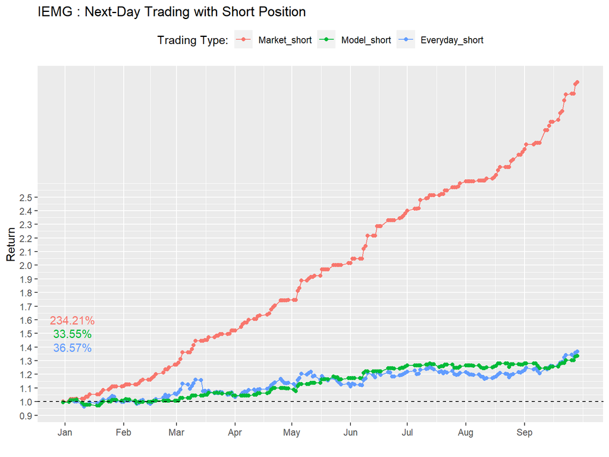

| Date | Sell | Invested Return | Actual Return | Daily Trade Return | Total Cumulative Return |
| --- | --- | --- | --- | --- | --- |
| 12/31/21 | * | -0.5830% | 0.5830% | -582,992 | -582,992 |
| 01/03/22 | * | 0.3827% | -0.3827% | 382,726 | -202,497 |
| 01/04/22 | * | 1.5119% | -1.5119% | 1,511,868 | 1,306,310 |
| 01/05/22 |  | 0.0000% | 0.3717% | 0 | 1,306,310 |
| 01/06/22 |  | 0.0000% | 0.8898% | 0 | 1,306,310 |
| 01/07/22 | * | 0.0836% | -0.0836% | 83,610 | 1,391,012 |
| 01/10/22 | * | -2.1186% | 2.1186% | -2,118,586 | -757,044 |
| 01/11/22 | * | -1.6406% | 1.6406% | -1,640,578 | -2,385,202 |
| 01/12/22 |  | 0.0000% | -1.4279% | 0 | -2,385,202 |
| 01/13/22 |  | 0.0000% | -0.0163% | 0 | -2,385,202 |

[output cut: 178 more lines]

# 3. Conclusion and Future Development

The time series models performed quite well. However, its performance drop during period of interest rate hike. We could relax the cut-off value a bit to retain more of the competitive edge from short selling, and closely monitor the trading results to wait for the accuracy to come back to 60% to resume action. Yet, the above two methods are only superficial. To address the issue, we should add other methods to predict the timing and magnitude of reaction for upcoming events in general. For example, models for months that have interest rate hike. During the particular event period, we extend our trading windows and limit the next-day trading to benefit from longer term trend and to guard against volatile short term market. That is, event driven predictive models or short term swing trading methods. Combining the advantage of regime switching models and event driven models, the predictive model as a whole could be more robust and capture more gains from tough market conditions.